# MethylPhys CPG Physics of Methylation: Landauer Metrology · Cellular Performance Gauge · the physics of methylation, read against a fixed zero

view:

REFERENCE · composition verified: whole blood · generated 2026-09-30 00:58 · repo a7a4400

## Reading - REFERENCE

| Specimen | whole_blood | Substrate | DNA methylation (450K/EPIC beta) |
| --- | --- | --- | --- |
| Declared age | 60.0 | Pipeline map | MAPPED(stage1_noob_450K->roadmap; slope 1.0127, intercept 0.0662; v1 COMMISSIONED 2026-09-20 (Phase 1c)) |
| Laboratory | - | Foreign-cell detection | commissioned for this laboratory |

**Healthy is A = 1.00.** Every cell type has one physical floor, the H_min of its architecture class, and a healthy cell of any type reads A = H / H_min = 1.00 on it. NORMAL is 0.95-1.05; below 0.95 is SUPPRESSED; 1.05-1.07 ELEVATED; the 1.07 Warburg line and the 1.10 breach line are the physics' two inflection points. The reading below is each cell in this sample against its own floor. Nothing about any population is part of any number on this page.

### 1. What is in the sample, and how each cell reads

| cell | class | fraction | A | 95 % interval on the reading | tier |
| --- | --- | --- | --- | --- | --- |
| Neutrophils_reinius | Immune & haematopoietic | 62.7 % | **1.0460** | 1.0446 - 1.0476 | NORMAL |
| CD56_NK-cells | Immune & haematopoietic | 14.1 % | **0.9959** | 0.9939 - 0.9980 | NORMAL |
| CD4_T-cells | Immune & haematopoietic | 11.8 % | **1.0594** | 1.0575 - 1.0612 | ELEVATED |
| CD8_T-cells | Immune & haematopoietic | 6.1 % | **1.0010** | 0.9987 - 1.0031 | NORMAL |
| CD14_monocytes | Immune & haematopoietic | 3.3 % | **1.0536** | 1.0520 - 1.0551 | ELEVATED |
| Glia | Terminal / post-mitotic | 1.0 % | **1.1092** | 1.1052 - 1.1130 | BREACH |

**6 cells found above the presence floor.** 3 read NORMAL. Outside NORMAL: **CD4_T-cells** at A = 1.0594 (ELEVATED, above 1.00 by 0.0594); **CD14_monocytes** at A = 1.0536 (ELEVATED, above 1.00 by 0.0536); **Glia** at A = 1.1092 (BREACH, above 1.00 by 0.1092).

2 atlas cells placed below the presence floor - detected in trace amounts, not scored (a cell must be present to be measured; fraction is a detection gate, not a correction to A). 76 entries not resolvable on this platform. Every cell, scored or not, is on the **Every cell** tab. A is H(mean beta over the cell's identity loci) / H_min of its class, on scale-mapped betas. Nothing is added to or subtracted from it. The tier is read on A against 1.00 on the tier scale (NORMAL 0.95-1.05). Each cell's 95 % interval and identifiability are on the **Every cell** tab.

### 2. Foreign cells - is there anything in this blood that is not blood?

**No foreign template above its noise floor.**

### 3. The instrument

**Laboratory -** · pipeline map `MAPPED(stage1_noob_450K->roadmap; slope 1.0127, intercept 0.0662; v1 COMMISSIONED 2026-09-20 (Phase 1c))` (this laboratory's processing route onto the atlas scale, fitted on paired reads) · foreign-cell detection commissioned (panel n = 732). The commissioning panel calibrates the instrument - what this scanner and this processing do to a known input - and never the definition of healthy.

Internal gate: the pooled class gauge runs only to ask whether this specimen is blood-like (composition verified: **True**, foreign fraction 0.0). A pooled class A is not a reading and is not printed; the cells are.

**Go deeper on the gauge.** Everything on this tab is treated at full length in the Operations Manual - [MethylPhys CPG Operations Manual](https://github.com/hmahaffeyges/IAM-Validation/blob/a7a4400/Biological_Physics/MethylPhys/manual/MethylPhys_CPG_Operations_Manual.pdf) (the physics section, every sealed procedure with its outcome as found, the complete validation history, the reconciliation tables, the falsification register and the future-goals list) - and in the short methods paper, [Physics of Methylation: Landauer Metrology (PDF)](https://github.com/hmahaffeyges/IAM-Validation/blob/a7a4400/Biological_Physics/MethylPhys/papers/Physics_of_Methylation__Landauer_Metrology.pdf). Both live in the same repository as the code that produced this page, at the same commit.

Reference material - this tab is the same in every report and carries no measurement of this specimen.

## How to read the gauge

A thermometer is only useful if its reading means something definite. This tab sets out what A means at each level, where the lines are, and - just as important - what the reading does not claim. **The instrument reports a cellular state; the clinician decides what to do about it.** The roles are distinct and kept distinct on purpose.

### What A is measuring

A does not measure how many cells there are, or how large a mass is, or whether anything is present anywhere. It measures one thing: **how much informational fidelity a cell holds against the minimum its identity requires - A = H / H_min** - in plain terms, how well a cell is still maintaining its own identity. A well-differentiated cell doing its job sits at 1.00; a cell that has lost its architectural fidelity reads high. This is closer to a measure of *grade* (degree of dedifferentiation) than of size or burden, and that distinction is what makes the reading behave the way a clinician would want.

### The test for any number on this report

**Could this number exist if nobody else's sample had ever been measured?** Every number on a reading passes it: H, the floor H_min, A, the array's own calibration. A band, a percentile, an age curve or a range of people would fail it - which is why none is printed. A cell's class only names the floor it is divided by; no class has an A.

### Where the locker analogy helps

Think of a school with eight grades, every student with a locker. Most lockers tell you nothing about the grade. Some are characteristic: every ninth-grader's holds the same geometry book. Those are the identity lockers. The gauge walks the identity lockers for one cell and asks how consistently they still hold what that class's lockers hold. It is not counting students.

### The levels

Every reading on this report is **one cell type's A**: the entropy of the mean methylation over that cell's identity addresses, divided by the frozen floor H_min of its architecture class. Healthy is A = 1.00 by the physics; the tier scale below is the tolerance around it, read from one file (`tier_breakpoints.json`) by one function.

| level | on the gauge | what it means |
| --- | --- | --- |
| **SUPPRESSED - below 0.95** | A below 0.95 | the cell is holding its pattern more tightly than its identity requires. Real, and not automatically good: strongly hypomethylated states read here (post-chemotherapy and immunosuppressed samples sit … |
| **NORMAL - 0.95 to 1.05** | A within 5 % of 1.00 | the cell is holding its identity pattern within five per cent of the entropy its identity costs. Symmetric about the fixed point; no population defines the edges. |
| **ELEVATED - 1.05 to 1.07** | A above 1.05 | the pattern is measurably looser than its identity requires. The cell is drifting. This is the regime where a reading is worth a second sample or a closer look, and where nothing has failed yet. |
| **at 1.07 - the Warburg line** | WARBURG_TRANSITION (a line, not a band) | the cell has flipped toward aerobic glycolysis. This is a boundary in the intervention strategy, not in the arithmetic - see below. |
| **at 1.10** | BREACH | the no-return line. The cell is no longer holding its identity pattern at the level that defines it. |

### Age

The declared age is carried as context on the record and is not an operand of any reading.

### Two different things, and neither is A = 1.00 sitting on a floor

This is worth getting exactly right, because one is a physical constant and one is the fixed point, and they are easy to conflate.

|  | what it is | where it sits | what crossing it means |
| --- | --- | --- | --- |
| **A = 1.00** the fixed point | a cell holding exactly the entropy its identity costs. It is the *middle of the green band*, not an edge of anything. | mid-NORMAL. NORMAL (0.95-1.05) is the tolerance about it. | nothing - it is the point everything else is measured from. |
| **H_min(class)** the class entropy reference | a **constant in the denominator**, in bits: the entropy level below which that architecture cannot hold the pattern that makes it that kind of cell. It is what makes A dimensionless. | it is *not a mark on the A axis at all*. It is the unit the axis is drawn in. | a reading that falls well below 1.00 is the suppressed / inverted direction - the pattern is over-ordered or erased rather than loosened (post-chemotherapy and immunosuppressed samples sit near 0.90). |

### The saturation wall chart - 8 classes x 5 substrates

Each cell shows the class's frozen floor H_min on that substrate; the flags are the author's own from the Issue 002 saturation wall chart: **SAT** = saturates below the breach line at 1.1, so that substrate cannot register a floor breach for that class; **TGT** = tight headroom (saturates below 1.15), where a severe departure approaches saturation; unflagged = full headroom past breach. The floors come from the frozen 40-value table (methylation from the G-002 calibration, the four cfDNA/chromatin substrates from G-003b). Only the methylation column is lit today - see Coverage.

| class | methyl (lit) | nucl | fuzz | wps | frag |
| --- | --- | --- | --- | --- | --- |
| Stem (pluripotent) | 0.9822 **SAT** | 0.7998 | 0.9629 **SAT** | 0.9050 **TGT** | 0.9736 **SAT** |
| Stem (adult) | 0.8737 **TGT** | 0.9609 **SAT** | 0.9808 **SAT** | 0.9890 **SAT** | 0.8413 |
| Progenitor | 0.8522 | 0.9728 **SAT** | 0.9619 **SAT** | 0.9880 **SAT** | 0.8090 |
| Cycling epithelial | 0.8561 | 0.9801 **SAT** | 0.8190 | 0.6274 | 0.6879 |
| Secretory / glandular | 0.8433 | 0.9826 **SAT** | 0.8479 | 0.6345 | 0.6977 |
| Immune & haematopoietic | 0.8389 | 0.9899 **SAT** | 0.8304 | 0.5896 | 0.7115 |
| Terminal / post-mitotic | 0.7728 | 0.9920 **SAT** | 0.7370 | 0.9589 **SAT** | 0.6249 |
| Stromal & connective | 0.8629 | 0.9857 **SAT** | 0.8324 | 0.6127 | 0.7247 |

### The Warburg line at 1.07

A boundary LINE at A=1.07, not a tier band. The metabolic point of no return for one specific class of intervention: at this threshold the cell has flipped toward aerobic glycolysis (the Warburg effect), and the consequence is counterintuitive and clinically crucial — adding metabolic fuel past this point can ACCELERATE the drift rather than correct it. The same supplementation that helps below 1.07 can feed the glycolytic program above it. The holistic metabolic strategy must change character here: from supporting normal metabolism to forcing a return to oxidative metabolism or turning to structural approaches. For a practice built on metabolic and lifestyle levers, 1.07 is arguably the single most important number on the gauge, because it marks where the toolkit itself has to change.

**How it is placed.** 1.07 is a boundary *line* in the breakpoints file, not a tier band - the file carries it with a null range and an explicit anchor flag, so no reading is ever labelled 'Warburg'; the line is reported as crossed or not. Its value is inherited from the Issue 002 tier system, where it was set from the published methylation range over which the glycolytic program becomes structurally committed, and it has not been re-derived on the commissioned chain. That re-derivation - measuring where the metabolic and structural regimes actually part on this gauge - is a named open item, and until it is done the line should be read as the corpus's stated boundary rather than a result of this chain.

The clinician-facing wording the file itself carries: *Your A-score crosses the Warburg metabolic transition line at 1.07. Below this line, adding metabolic support (nutrients, fuel) tends to help. Above it, the same intervention can accelerate the drift instead of correcting it — the metabolic regime has shifted toward aerobic glycolysis. Your clinician should know about this transition specifically; the intervention strategy above this line is materially different from below it.*

### What a high reading does not mean

A high reading is a statement about the state of a cell population, not a clinical conclusion. Being precise about this matters, because over-reading it is exactly the failure mode the instrument must avoid.

- **It does not locate anything.** The reading says that cells of a given class with loosened fidelity are detectable in this specimen - not where they are, nor whether they have organised into anything. Localising is the clinical workup, not the reading.
- **It does not name a cause.** The same threshold is crossed by senescent cells. The level marks a regime, not a mechanism; which mechanism applies is a separate question A alone does not answer, and this report never guesses at it.
- **It does not mean inevitability.** It means a population has crossed into the regime where structural fidelity is lost. What follows depends on biology, location, burden and clinical response - none of which this instrument measures.
- **It is not a grade of any lesion.** A tracks epigenomic fidelity, which correlates with histological grade but is its own axis. It does not replace histology. What it does is tell you *which compartments have drifted and by how much*, so that attention goes where the cells have actually changed.

The honest reading of a high value is therefore: *a population of cells in this compartment has lost structural fidelity, and this compartment warrants a closer look.* A prompt, not a conclusion.

### Would a well-differentiated benign growth read high?

In general it should not, and that is the question that reveals what the instrument measures. A lipoma, a fibroid or a simple nevus is made of cells that are still recognisably their own type - they have lost growth control, not identity. Because A reads identity fidelity rather than cell number, a well-differentiated benign lesion is expected to read at or near 1.00. **The instrument is not tripped by the presence of extra cells; it responds to the loss of what makes a cell that kind of cell.** The corollary is that a reading is independent of a lesion's shape - a flat lesion produces the same reading as a raised one, because the instrument reads methylation entropy rather than looking for a shape.

An ordered series - normal, benign neoplasm, dysplasia, the established condition - read on the commissioned chain is a named next test; until it has been run this report claims nothing about it.

### Two things the gauge is not

- **Not a clock.** Age is not an operand of any reading and this report never prints an age.
- **Not a fuel measurement.** The energy the cell spends holding its pattern is real, but A measures the pattern, not the fuel. A cell can be starving with a tidy pattern or well fed with a scrambled one.

**Go deeper on reading the gauge and the tiers.** Everything on this tab is treated at full length in the Operations Manual - [MethylPhys CPG Operations Manual](https://github.com/hmahaffeyges/IAM-Validation/blob/a7a4400/Biological_Physics/MethylPhys/manual/MethylPhys_CPG_Operations_Manual.pdf) (the physics section, every sealed procedure with its outcome as found, the complete validation history, the reconciliation tables, the falsification register and the future-goals list) - and in the short methods paper, [Physics of Methylation: Landauer Metrology (PDF)](https://github.com/hmahaffeyges/IAM-Validation/blob/a7a4400/Biological_Physics/MethylPhys/papers/Physics_of_Methylation__Landauer_Metrology.pdf). Both live in the same repository as the code that produced this page, at the same commit.

## Every cell - all 115 atlas cell types

**One surface, one formula, one gauge.** A = H(mean beta over the cell's IDENTITY loci) / H_min of its architecture class (RULING A3; LESSON-SURFACE-01). H_min is the minimum entropy a cell of that class must hold to keep its identity; A is where the cell sits on that bar - its informational fidelity against its own minimum requirement. The gauge reads 1.00 when the cell holds exactly what its identity costs; the tier scale (NORMAL 0.95-1.05) is the tolerance about that point. Nothing about any person or group is part of this number. Where people of a given age sit on the gauge is a separate observation about people, reported as such and never applied to a cell.

**What each column is, and why an instrument prints it**

| column | what it is | why it is on the page |
| --- | --- | --- |
| cell type | one of the 115 atlas cell types | the object being measured - a gauge reads one object at a time |
| present | the cell's fraction is above its presence floor | the detection gate. Below it the cell's identity loci carry OTHER cells' bytes and read by artefact (PROC-CEIL-01). A scale with nothing on it prints no weight |
| fraction | the deconvolved share of the sample's DNA that is this cell | how much of the object is on the scale - so the reading is known to be OF this cell. Never a correction to A |
| A | H(mean beta over the cell's identity loci) / H_min of its class | the measurement. Landauer floor in the denominator, measured entropy in the numerator; absolute and dimensionless |
| 95 % interval on the reading | resample THIS array's identity loci for the cell | repeatability of this reading - how far A moves if the cell's loci had been sampled differently. From the specimen, not from anyone else |
| tier | A against 1.00 on the tier scale (tier_breakpoints.json) | the tolerance about the fixed point, one file, one function |
| identity loci on this platform | how many of the cell's identity addresses exist on this array type (450K or EPIC), out of the atlas's list for the cell | coverage of the instrument, NOT a finding: every address reads something whether or not the cell is in the sample. Presence is the separate question answered by the fraction |
| identifiability | exclusive loci against the nearest rival cell, and whether the cell is solved alone, as a family, or not at all on this platform | what the detector can and cannot distinguish. Says whether 'this is a CD4 T-cell' is a defensible statement or a shared reading |

**A cell below its presence floor gets no A and no tier.** PROC-CEIL-01 measured why: an absent cell's identity addresses carry the specimen's other cells, which average near a coin flip, so an absent cell reads high or low by artefact. Its row says *not present - not scored*. Fraction is a detection gate, never a correction to A. A resolution family shares ONE fraction (the array cannot split it) but every member is scored on its own identity loci and prints its own A.

### What limits a per-cell claim

**Resolvability is a property of the atlas and the platform, not of your sample.** Two cells whose atlas profiles cannot be told apart on this array's loci are solved as one *resolution family* with one shared fraction; each member still prints its own A on its own identity loci. A cell whose atlas entry is defined on too few of this platform's loci is *not resolvable* and is listed, never printed as fraction 0. The **exclusive loci** column counts identity addresses at which this cell differs from its nearest rival by more than 0.2 beta - the more there are, the more the reading is about this cell and not a shared block.

**Resolvability.** 69 atlas entries are defined on under 1 % of this platform's loci and are not solved for (listed at the end); 7 lower-coverage copies of solved cells were folded into their originals (B-cells_EPIC = CD19_B-cells, CD4T-cells_EPIC = CD4_T-cells, CD8T-cells_EPIC = CD8_T-cells, Erythrocyte_progenitors = CMP, Monocytes_EPIC = CD14_monocytes, NK-cells_EPIC = CD56_NK-cells, Neutrophils_EPIC = Neutrophils_reinius); **resolution families**, solved as one column with one fraction shared by every member: Antrum_diff + Corpus_diff + Fundus_diff; Antrum_undiff + Corpus_undiff + Fundus_undiff; CMP + MEP.

### Foreign-cell detection (Stage 2d)

One joint fit of this specimen's panel markers on the blood reference and all 21 foreign templates; each template's floor is the instrument's noise floor, the 0.99 quantile over 732 arrays known to lack the cell (PROC-STAGE2D-03). A cell is named when one template clears its floor; three or more together read as epithelial-like material with the cell not resolved (measured on 1.9 % of healthy arrays, the oldest). A detected foreign cell prints its fraction; its A is not read below a scoring floor still to be tested.

A foreign cell is one that does not belong to whole blood. For each, the chain fits the specimen's own blood background, takes the residual, and asks how much of that cell's atlas profile is in it, weighting every locus by how quiet it is in healthy blood at commissioned laboratories. The reading is f̂ (an estimated fraction), with the laboratory's own line above which the chain says **detected**. The line is drawn from that laboratory's commissioning panel and from nothing else; a laboratory without a panel gets no line.

Laboratory **GSE87571** · panel n = 732 · 1506 markers · line rule: 0.99 quantile of f_hat over the 732 GSE87571 whole-blood arrays (Stage 1 with detection mask; call rate on the first 100 min 0.9728, none refused at 0.93); never the raw maximum. **No foreign cell above its line.**

| foreign template | f̂ | noise floor | standing bias on blood | detected | measured detection limit (90 %) |
| --- | --- | --- | --- | --- | --- |
| Glia | 0.01061 | 0.01621 | 0.00399 | no | 5 % |
| Thyroid | 0.00595 | 0.01249 | 0.00020 | no | 2 % |
| Bladder | 0.00000 | 0.00281 | 0.00000 | no | 10 % |
| Breast | 0.00000 | 0.01228 | 0.00000 | no | 10 % |
| Colon_epithelial_cells | 0.00000 | 0.00665 | 0.00000 | no | 5 % |
| Cortical_neurons | 0.00000 | 0.00000 | 0.00000 | no | 5 % |
| Head_and_neck_larynx | 0.00000 | 0.01526 | 0.00000 | no | 10 % |
| Hepatocytes | 0.00000 | 0.00206 | 0.00000 | no | 5 % |
| Kidney | 0.00000 | 0.00000 | 0.00000 | no | 5 % |
| Left_atrium | 0.00000 | 0.00000 | 0.00000 | no | 10 % |
| Lung_cells | 0.00000 | 0.00139 | 0.00000 | no | 5 % |
| Pancreatic_acinar_cells | 0.00000 | 0.00000 | 0.00000 | no | 5 % |
| Pancreatic_beta_cells | 0.00000 | 0.00000 | 0.00000 | no | 5 % |
| Pancreatic_duct_cells | 0.00000 | 0.00212 | 0.00000 | no | 5 % |
| Prostate | 0.00000 | 0.00351 | 0.00000 | no | 10 % |
| Upper_GI | 0.00000 | 0.00000 | 0.00000 | no | 10 % |
| Uterus_cervix | 0.00000 | 0.00000 | 0.00000 | no | 5 % |
| adipocyte | 0.00000 | 0.00000 | 0.00000 | no | 5 % |
| endothelial | 0.00000 | 0.00000 | 0.00000 | no | 5 % |
| family:Antrum_diff+Corpus_diff+Fundus_diff | 0.00000 | 0.00045 | 0.00000 | no | 5 % |
| family:Antrum_undiff+Corpus_undiff+Fundus_undiff | 0.00000 | NOT DETECTABLE on this block - not resolved from its differentiated family on this block: 0 % detected at 5 %, 17 % at 10 % |  |  |  |

The measured detection limit is the smallest spiked fraction the detector found in at least 90 % of trials at this false-positive rate (PROC-MF-02/03, four 450K laboratories). A cell without one has a line but no measured sensitivity; a detection on it is a reading to follow up, not a result. A detection of a foreign cell is a statement about *presence*; the cell's A-score is a separate reading and is printed only where the cell clears its presence floor.

### Stem (pluripotent) (1 cells; H_min 0.9822)

| cell type | present | fraction | A | 95 % interval on the reading | tier | identity loci on this platform | identifiability |
| --- | --- | --- | --- | --- | --- | --- | --- |
| stem_pluri | - | 0.0 % | - | - | not present - not scored | 13802 of 19505 | not in this platform's solve block (defined on too few of its loci) - fraction is not solved for |

### Stem (adult) (1 cells; H_min 0.8737)

| cell type | present | fraction | A | 95 % interval on the reading | tier | identity loci on this platform | identifiability |
| --- | --- | --- | --- | --- | --- | --- | --- |
| HSC | - | 0.0 % | - | - | not present - not scored | 29086 of 37987 | 0 exclusive loci · not separable from L-MPP, MPP |

### Progenitor (11 cells; H_min 0.8522)

| cell type | present | fraction | A | 95 % interval on the reading | tier | identity loci on this platform | identifiability |
| --- | --- | --- | --- | --- | --- | --- | --- |
| GMP | - | 0.0 % | - | - | not present - not scored | 28358 of 38581 | 9 exclusive loci · solved alone |
| L-MPP | - | 0.0 % | - | - | not present - not scored | 31106 of 41324 | 0 exclusive loci · not separable from HSC, MPP |
| CMP | - | 0.0 % | - | - | not present - not scored | 32861 of 43442 | 38 exclusive loci · family: CMP+MEP |
| MEP | - | 0.0 % | - | - | not present - not scored | 30053 of 42500 | 38 exclusive loci · family: CMP+MEP |
| MPP | - | 0.0 % | - | - | not present - not scored | 36839 of 55079 | 0 exclusive loci · not separable from HSC, L-MPP |

### Cycling epithelial (19 cells; H_min 0.8561)

| cell type | present | fraction | A | 95 % interval on the reading | tier | identity loci on this platform | identifiability |
| --- | --- | --- | --- | --- | --- | --- | --- |
| Head_and_neck_larynx | - | 0.0 % | - | - | not present - not scored | 135 of 201 | 43 exclusive loci · solved alone |
| Lung_cells | - | 0.0 % | - | - | not present - not scored | 87 of 120 | 101 exclusive loci · solved alone |
| Colon_epithelial_cells | - | 0.0 % | - | - | not present - not scored | 57 of 101 | 284 exclusive loci · solved alone |
| Bladder | - | 0.0 % | - | - | not present - not scored | 116 of 161 | 77 exclusive loci · solved alone |
| Uterus_cervix | - | 0.0 % | - | - | not present - not scored | 94 of 127 | 25 exclusive loci · solved alone |
| Kidney | - | 0.0 % | - | - | not present - not scored | 136 of 199 | 95 exclusive loci · solved alone |
| Upper_GI | - | 0.0 % | - | - | not present - not scored | 95 of 125 | 31 exclusive loci · solved alone |
| Antrum_undiff | - | 0.0 % | - | - | not present - not scored | 19610 of 23510 | 0 exclusive loci · family: Antrum_undiff+Corpus_undiff+Fundus_undiff |
| Fundus_undiff | - | 0.0 % | - | - | not present - not scored | 21933 of 25603 | 0 exclusive loci · family: Antrum_undiff+Corpus_undiff+Fundus_undiff |
| Corpus_undiff | - | 0.0 % | - | - | not present - not scored | 24130 of 27925 | 0 exclusive loci · family: Antrum_undiff+Corpus_undiff+Fundus_undiff |

### Secretory / glandular (18 cells; H_min 0.8433)

| cell type | present | fraction | A | 95 % interval on the reading | tier | identity loci on this platform | identifiability |
| --- | --- | --- | --- | --- | --- | --- | --- |
| Thyroid | - | 0.7 % | - | - | not present - not scored | 60 of 78 | 113 exclusive loci · solved alone |
| Pancreatic_acinar_cells | - | 0.0 % | - | - | not present - not scored | 179 of 242 | 208 exclusive loci · solved alone |
| Pancreatic_duct_cells | - | 0.0 % | - | - | not present - not scored | 87 of 114 | 87 exclusive loci · solved alone |
| Prostate | - | 0.0 % | - | - | not present - not scored | 136 of 182 | 64 exclusive loci · solved alone |
| Breast | - | 0.0 % | - | - | not present - not scored | 151 of 228 | 74 exclusive loci · solved alone |
| Hepatocytes | - | 0.0 % | - | - | not present - not scored | 101 of 157 | 228 exclusive loci · solved alone |
| Corpus_diff | - | 0.0 % | - | - | not present - not scored | 22225 of 25084 | 0 exclusive loci · family: Antrum_diff+Corpus_diff+Fundus_diff |
| Antrum_diff | - | 0.0 % | - | - | not present - not scored | 22891 of 26776 | 0 exclusive loci · family: Antrum_diff+Corpus_diff+Fundus_diff |
| Fundus_diff | - | 0.0 % | - | - | not present - not scored | 22516 of 26536 | 0 exclusive loci · family: Antrum_diff+Corpus_diff+Fundus_diff |
| Pancreatic_beta_cells | - | 0.0 % | - | - | not present - not scored | 161 of 220 | 119 exclusive loci · solved alone |

### Immune & haematopoietic (51 cells; H_min 0.838889)

| cell type | present | fraction | A | 95 % interval on the reading | tier | identity loci on this platform | identifiability |
| --- | --- | --- | --- | --- | --- | --- | --- |
| CD4_T-cells | yes | 11.8 % | 1.0594 | 1.058 - 1.061 | ELEVATED | 20735 of 32625 | 50 exclusive loci · solved alone |
| CD14_monocytes | yes | 3.3 % | 1.0536 | 1.052 - 1.055 | ELEVATED | 18556 of 27844 | 60 exclusive loci · solved alone |
| Neutrophils_reinius | yes | 62.7 % | 1.0460 | 1.045 - 1.048 | NORMAL | 18613 of 28344 | 33 exclusive loci · solved alone |
| Eosinophils_reinius | - | 0.0 % | - | - | not present - not scored | 18968 of 29102 | 21 exclusive loci · solved alone |
| CD19_B-cells | - | 0.3 % | - | - | not present - not scored | 21456 of 34266 | 127 exclusive loci · solved alone |
| CD8_T-cells | yes | 6.1 % | 1.0010 | 0.999 - 1.003 | NORMAL | 23136 of 40493 | 22 exclusive loci · solved alone |
| CD56_NK-cells | yes | 14.1 % | 0.9959 | 0.994 - 0.998 | NORMAL | 24174 of 41276 | 69 exclusive loci · solved alone |

### Terminal / post-mitotic (9 cells; H_min 0.7728)

| cell type | present | fraction | A | 95 % interval on the reading | tier | identity loci on this platform | identifiability |
| --- | --- | --- | --- | --- | --- | --- | --- |
| Cortical_neurons | - | 0.0 % | - | - | not present - not scored | 31287 of 49743 | 81 exclusive loci · solved alone |
| Glia | yes | 1.0 % | 1.1092 | 1.105 - 1.113 | BREACH | 24961 of 42066 | 255 exclusive loci · solved alone |
| Left_atrium | - | 0.0 % | - | - | not present - not scored | 229 of 322 | 40 exclusive loci · solved alone |

### Stromal & connective (5 cells; H_min 0.863)

| cell type | present | fraction | A | 95 % interval on the reading | tier | identity loci on this platform | identifiability |
| --- | --- | --- | --- | --- | --- | --- | --- |
| endothelial | - | 0.0 % | - | - | not present - not scored | 1885 of 2402 | 37 exclusive loci · solved alone |
| adipocyte | - | 0.0 % | - | - | not present - not scored | 863 of 1214 | 60 exclusive loci · solved alone |

**69 atlas entries not resolvable on this platform (defined on under 1 % of its loci) - kept in the atlas as reference, not solved for**

Acinar, B, BE, Basal, Baso, Bcell, Bmem, Bnv, CD4T, CD4Tmem, CD4Tnv, CD8T, CD8Tmem, CD8Tnv, CM, Chol, Ductal, Endocrine, Eos, Eosino, Epi, Epi_basal, Epi_stratified, Epi_suprabasal, Epi_upper, Gland, Gran, Hep, IC, Kera_diff, Kera_undiff, Kup, LE, Leu, Luminal, Lym, MP, Macro, Mela, Microglia, Mono, Mye, NK, Neu, NeuIm, NeuMa, Neutro, OPC, Oligo, PBMC, Plasma, Tcell, Treg, dendritic, eosinophil, erythroblast, fibroblast, granulocytes, macrophage, megakaryocyte, monocyte, nRBC, neuron, neutrophil, small_intestine, smooth_muscle, stromal_other, tcell, whole_blood

**Direction - Stage 4.5 bidirectional composite (a panel-derived quantity kept for the record, not a reading: a per-cell A below or above 1.00 already carries direction)**

Pooled entropy folds hypo- and hyper-methylation together; the signed composite keeps the sign, per sealed panel. Panels exist only where one was sealed (immune, VAL-051 / CPG-VAL-019); the other classes say so.

[output not shown]

## The sky - what it is, why it is a cosmologist's object, and what it buys a geneticist

This page is not an analogy. Every step below is a measurement problem cosmologists had to solve before the microwave background could be read at all, and each has a counterpart this chain already runs. The point of putting a methylome on a sphere is not that the picture resembles theirs - it is that **thirty years of machinery for reading a noisy field on a sphere becomes available**, with the names changed.

### A sky map is not a photograph

This is the first thing cosmology had to unlearn. What Planck delivers is not a picture of the sky; it is *the residual left after a model is subtracted from a measurement*, at a declared resolution, with a mask over the parts that cannot be measured, and a noise level quoted per pixel. The famous image is the last step of a long pipeline, and every step of that pipeline had to be invented. Two of those steps decide everything: the monopole (2.725 K) and the dipole (the Earth's own motion through the radiation) are real, enormous, and *not the signal*. Remove them wrongly and the anisotropy - one part in 100,000 - is buried a thousand times over. That is not a subtlety; it is the measurement.

### The correspondence, step by step

| what cosmology had to learn | why it mattered | what it is in this chain |
| --- | --- | --- |
| Subtract the monopole and dipole before anything else | they are real and they are not the signal | nothing is subtracted from the sky or from a cell's A. The residual is this specimen against its own composition expectation; A = 1.00 is the physical fixed point. Whether the array's own probes can t… |
| Mask the galaxy | part of the sky cannot be measured; do not guess what is behind it | the **presence floors**. **Below its floor a class is not there** - the specimen holds no detectable amount of it - so the chain masks it black and reports nothing about it. *The analogy is close but … |
| Component separation - dust, synchrotron, free-free | you cannot read the sky until you separate what lies in front of it | **Stage 2, the composition step.** Not a loose parallel: the second solver in this chain *is* NILC, the needlet internal linear combination Planck used, pointed at cell types instead of foregrounds |
| Deconvolve the instrument beam | resolution is finite and must be declared, not assumed | about 2.2 CpG addresses per pixel at NSIDE 128 is this instrument's beam. The smoothed panel in the figure below is the beam-smoothed map, which is the only fair comparison to a published CMB image |
| A noise covariance per pixel, not one number for the map | pixels are not equally trustworthy | each address's **own sigma**: the atlas posterior at that address combined with this array's own SNP-probe noise - the denominator of every z on this page. No other person's array enters it |
| Score anomalies against simulations, never an analytic null | a real sky carries built-in correlations, so a Gaussian null is simply the wrong null | the **spatially-shuffled null** - and this chain has now measured exactly why it is required (the warning further down) |
| Then, and only then, the angular power spectrum | the *scale* of the structure is where the physics lives | **not built - this is the frontier.** What it would be worth is the next paragraph |

### What this buys a geneticist that a list of differentially methylated regions does not

Epigenomics today answers *which CpGs moved*: per-site tests with a false-discovery correction, or differentially methylated regions found in windows whose size is chosen in advance. Both force you to pick a scale before you look. A spectrum asks a different question - **at what genomic scale does this departure live?** - and answers it at every scale at once with no window chosen. The multiple-comparison problem comes with it: cosmology calls it the *look-elsewhere effect* and has spent decades on it, and its answer is simulation rather than dividing an alpha by a large number.

The spatial correlation measured here is the first point of that spectrum. A healthy methylome has a characteristic correlation scale. **If a condition changes that scale rather than the value at any single address, a spectrum sees it and no per-site test can.** That is a new and falsifiable observable, and it is the reason this is a method rather than a picture.

### One thing a geneticist has that a cosmologist would trade almost anything for

There is one microwave sky. It cannot be re-observed, it will not change, and every cosmological anomaly argument is limited by that single realisation. **A methylome sky can be measured again on the same person.** Two draws six months apart give a difference map - and a difference map is where this whole toolkit is strongest, because the static structure (the genomic correlation, the laboratory's own character, that individual's baseline) cancels and only what changed survives. That is not a metaphor; it is an experimental design a clinic can execute, and it is the strongest argument for treating a methylome this way.

### What else the MCMC gives us, and what we are not yet using

The atlas does not store one number per cell type per address. It stores the **posterior mean, the posterior SD and the credible-interval bounds** - 122 standard-deviation columns with interval columns beside them - because MCMC produces a distribution, and keeping only its centre throws away most of what was computed. Two uses are live: the floors were fitted this way and frozen; and a second, posterior-weighted solver cross-checks the composition.

**What the atlas does not carry, measured.** A cross-class covariance at an address would let the composition step say *these two are individually uncertain but their sum is well determined*. PROC-COV-01 (2026-09-26) checked the MCMC archives: only marginal summaries were written, each locus's posterior is independent by model construction, and the classes were run as separate jobs - so no cross-class covariance was ever estimated and none can be recovered. The residual covariance on real specimens was measured instead and found to be a reproducible reference misfit, mostly removable; that is recorded in PROC_COV_01_OUTCOME.md.

### Brilliance - the first tool taken from cosmology, and where it went

The first CMB-derived instrument in this work was not the sky; it was **brightness**. Surface brightness is how astronomy states an intensity that does not depend on the distance to the source or the size of the telescope, and the brightness layer built alongside the atlas applied that idea to an architecture class: how strongly does this class shine at its own addresses, on a scale that does not depend on how much of it happens to be in the tube. That was the right instinct, and it is why a per-class expectation exists at all. The sky builds its expectation from *this sample's own composition*, which a precomputed per-class file cannot do. The lineage is worth stating, because the first import from cosmology is still load-bearing one layer down.

### Two maps from one patient - the difference map

In the author's words, and it is the strongest argument on this page: *a methylome sky can be re-measured on the same patient. Two draws six months apart gives a difference map - and difference maps are where cosmology's entire toolkit is most powerful, because the static foregrounds cancel. That is not a metaphor, it is an experimental design a clinic can execute, and it is the strongest reason the analogy is a method rather than a decoration.*

**Is it sensitive enough to see a change in one island? Measured, not asserted.** On the Uppsala panel the between-person spread per address is 0.029 in beta units (IQR 0.018-0.046). The quietest 5 % of addresses - spread 0.0089 - bound the purely technical part from above, since nothing can be quieter than the noise. A paired difference of two draws from one person removes that person's baseline and the genomic correlation, leaving technical noise times root two:

| addresses averaged | what that is | detectable change in methylation (2 sigma, paired) |
| --- | --- | --- |
| 1 | one CpG | 2.5 percentage points |
| 5 | a few sites in one promoter | 1.1 points |
| 20 | **a CpG island** | **0.6 points** |
| 100 | a small domain | 0.25 points |
| 1,000 | a large domain, or a class panel | 0.08 points |

Reported effects at a CpG island typically run from several to twenty points. **So yes: at island scale and above, a paired difference map should resolve changes an order of magnitude smaller than effects already in the literature**, and the limit is set by array noise rather than by anything in this chain. Two caveats travel with that. The technical term is an *upper bound inferred from cross-sectional data*, because **no repeat draws of the same person exist in anything held here** - the EPIC-Italy foundation arrays carry no subject identifier, so no second draw can be linked - and a real serial test must re-measure it from actual replicates. And a difference map cancels the laboratory only if both draws went through the same laboratory and pipeline; otherwise the pipeline map must be applied to each before differencing. A serial mode - the same patient read twice, with the difference printed - is a named next step of the chain.

### Is the sphere necessary? A straight answer

**For a clinician reading one patient, a sphere is probably the wrong picture,** and this page would rather say so than defend it. A geneticist thinks in chromosome coordinates and an ellipse has no chromosomes on it. Better formats for the clinical read: a **per-chromosome linear track** - immediately interpretable, the format every genome browser already uses - or a **Hilbert-curve layout**, a space-filling curve in the plane already used in genomics, which keeps locality about as well as the sphere while staying rectangular and printable. The sphere earns its place where the *statistics* are spherical. The intended end state is both: the sphere for the spectral analysis, a linear or Hilbert track for what a clinician sees, and the same residual underneath so the two cannot disagree.

### Acknowledgement - whose tools these are

Everything on this page except the biology was built by the cosmology community over some thirty years, out of necessity, because they had one noisy sky and no way to obtain another. HEALPix; the internal-linear-combination and needlet methods that make component separation work; beam deconvolution; per-pixel noise covariances; simulation-based nulls, and the discipline of scoring an anomaly against a null rather than against intuition - none of it was invented here. The contribution is the recognition that a methylome is the same kind of object and can be measured with the same instruments. **We are the messenger, not the inventor**, and the right response to a cosmologist reading this page is thanks.

What is handed over is also more than a ruler for cellular fidelity. It is a **toolkit, and a different way of seeing the methylome** - as a field on a manifold with a model, a mask, a beam and a noise budget, rather than as a list of sites with p-values attached. What a geneticist builds with that is not ours to predict, which is rather the point of handing it over.

**On precedence, stated the way a referee will read it.** We are not aware of prior work that projects a methylome onto a sphere and applies component-separation and sky-statistics machinery to it. The search behind that sentence, run 2026-09-22, with its actual counts rather than a summary: in **Europe PMC**, *spherical harmonic* + *methylome* returned **0**, *angular power spectrum* + *(methylation OR epigenome)* returned **0**, and *needlet* + *(genome OR methylation)* returned **0**; *HEALPix* + *methylation* returned **2** records and *HEALPix* + *genome* returned **4**, all of them structural-biology papers (cryo-EM structures of a vesicular stomatitis virus polymerase complex, human IAPP fibrils, and others) in which HEALPix appears as the orientation-sampling scheme and methylation only incidentally - none projects a methylome. A query pairing *cosmic microwave background* with *methylation* returns over 1,500 records and is pure abbreviation collision (CMB is also conditioned medium, chronic mountain sickness), which is why it is not evidence either way. In **arXiv**, five query forms - HEALPix + methylation, power spectrum + methylome, cosmic microwave background + epigenome, needlet + biological, spherical harmonics + DNA methylation - each returned **0**. Sanchez & Mackenzie brought the Landauer bound to methylation but no sky; CMB pipelines have not been pointed at a genome. **This is a bounded search, not a proof of absence**, and a reader who knows of prior work should say so. One detail worth keeping, because those two HEALPix hits make the point better than a zero would have: **HEALPix is already used in biology**, as the angular-sampling scheme for particle orientations in cryo-electron microscopy. The pixelisation is in the toolbox already; this is a different use of it.

### This sample's sky - Stage 4.6

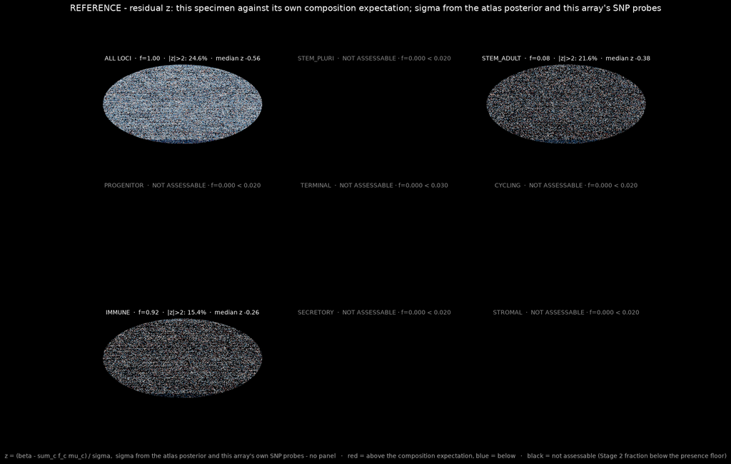

**THIS SPECIMEN: REFERENCE.** Rendered from this specimen's own residuals at this run. It is the only image on this page that is about this specimen; every other figure below is a reference illustration.

**Whole sky:** 124,634 addresses; 24.6 % beyond |z| = 2 (healthy 2.6-3.2 %); median z -0.563; mean |z| 1.682.

| class panel | Stage 2 fraction | presence floor | status | addresses | % beyond \|z\|=2 | median z |
| --- | --- | --- | --- | --- | --- | --- |
| Stem (pluripotent) | 0.0 % | 2 % | NOT ASSESSABLE · f=0.000 < 0.020 |  |  |  |
| Stem (adult) | 7.8 % | 2 % | ASSESSABLE | 36384 | 21.6 | -0.375 |
| Progenitor | 0.0 % | 2 % | NOT ASSESSABLE · f=0.000 < 0.020 |  |  |  |
| Cycling epithelial | 0.0 % | 2 % | NOT ASSESSABLE · f=0.000 < 0.020 |  |  |  |
| Secretory / glandular | 0.0 % | 2 % | NOT ASSESSABLE · f=0.000 < 0.020 |  |  |  |
| Immune & haematopoietic | 92.2 % | 2 % | ASSESSABLE | 32528 | 15.4 | -0.264 |
| Terminal / post-mitotic | 0.0 % | 3 % | NOT ASSESSABLE · f=0.000 < 0.030 |  |  |  |
| Stromal & connective | 0.0 % | 2 % | NOT ASSESSABLE · f=0.000 < 0.020 |  |  |  |

### The comparison figure

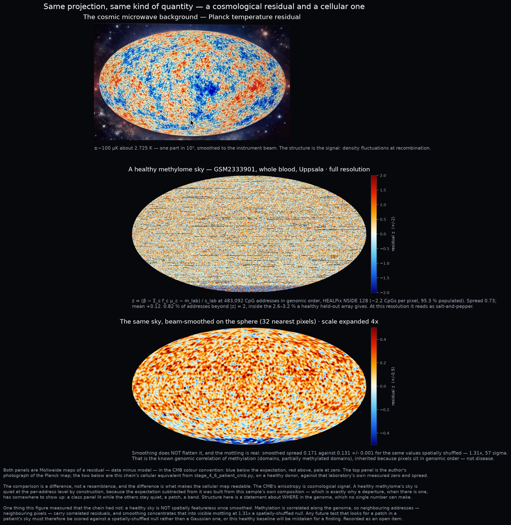

Top: the author's photograph of the Planck CMB temperature residual. Below it, a healthy methylome sky from this chain at full resolution and beam-smoothed, same projection, same colour convention. The comparison is a difference, not a resemblance, and the difference is what makes the cellular map readable. **Reference figure** - the same in every report, not this specimen.

**If you are going to look for a patch, a band or a region in one of these maps, read this first.** A healthy sky is **not** spatially featureless. Beam-smoothing a healthy sky on the sphere (32 nearest pixels) leaves a spread of 0.171, against 0.131 ± 0.001 for the same values spatially shuffled - **1.31×, 57σ**. That mottling is real: methylation is correlated along the genome, and this projection places pixels in genomic order, so neighbouring addresses carry correlated residuals. It is a property of healthy biology, not a departure.  
**Consequence: any test that looks for structure - a patch, a band, a region - must be scored against a SPATIALLY-SHUFFLED null, not a Gaussian one.** A Gaussian null will call this healthy baseline a finding every time. The per-address test this report prints (the fraction of addresses beyond |z| = 2) is per-pixel and therefore unaffected. Measured 2026-09-22 while building the figure above; recorded as an open item in the working note.

### How to read a plate

Blue = less methylated than this sample's own composition predicts at that address; red = more. A healthy plate is salt-and-pepper with no structure. Structure - a band, a patch, one class panel lit while the others are quiet - is what the sky is for: it shows *where in the genome* a departure lives, which no single number can. The plate is a residual map, the same object a cosmologist looks at after subtracting the model from the data.

Reference material - this tab is the same in every report and carries no measurement of this specimen.

## The physics, in plain language

**Who this is for.** The oncologist, the molecular biologist, the lab director, the informed reader. You do not need to follow a single line of physics to use what follows, and nothing in the first seven sections needs a formula. Where a constant appears it is a textbook constant, shown so that you can check it. The formulas are at the end, marked optional.

### 1. The one idea

Every living cell is doing the same thing every moment: **spending energy to hold itself in order against the natural pull toward disorder**. Order does not maintain itself. It has to be paid for, continuously, or it decays. This instrument measures how much margin a cell has between the order it is maintaining and the minimum cost of maintaining any order at all. That margin is the reading.

### 2. Where the number comes from - and why you will recognise every piece

This is the part worth seeing, because it shows the method rests on quantities you already know from biochemistry, not on anything exotic. For a human cell:

**n = ΔG<sub>ATP</sub> ÷ (R · T) = 54,000 ÷ (8.314 × 310.15) = 20.94**

| term | value | what it is |
| --- | --- | --- |
| ΔG<sub>ATP</sub> | ~54,000 J/mol | the free energy released by hydrolysing one mole of ATP under cellular conditions - the standard energy packet a cell spends to do one increment of ordering work. The same number in every cell-biology… |
| R | 8.314 J/mol·K | the gas constant - the bookkeeping constant that puts energy and temperature into the same units. |
| T | 310.15 K | body temperature. Exactly 37 °C, in Kelvin. |

So the denominator R·T is the *thermal energy scale at body temperature* - the size of a single random thermal kick at 37 °C, the noise packet trying to randomise the cell's order. And the ratio is simply **about 21 packets of ordering for every 1 packet of noise**. That is the whole foundation: two numbers any biochemist already carries, divided by each other. Nothing is hidden in it. What is new is not the ingredients - it is the recognition that their ratio defines a fixed floor of cellular existence, and that the same kind of floor appears in physical systems with no biology in them at all.

### 3. Why this is NOT metabolism - the distinction that matters most

The instant you say "ATP" and "body temperature", a clinician thinks *metabolism*. It is important to be precise: this is not a metabolic rate and not a BMR measurement.

- **Metabolism is a flow - a rate.** Calories *per day*. How fast the body burns fuel, rising with exercise, fever, illness. It has *time* in it: energy divided by time.
- **This margin is a ratio** - a proportion with no time in it. The size of one ordering packet compared with the size of one noise packet. Energy divided by energy. You could freeze a cell at a single instant and the margin would still be 20.94.

*Metabolism is the river's flow rate. This is the river's depth relative to the rocks. Same water - but one is how fast it moves, the other is how far it sits above the bottom.*

The tell is the units: metabolism has *per day* in it; the margin has no time in it at all. A patient with a perfectly normal metabolism can still have a cell population whose margin has narrowed - and that narrowing is what this reads and a metabolic panel cannot.

### 4. Three things, not two

It is tempting to say "ATP is the information and temperature is the noise", but the clean picture has three parts, and the distinction matters:

| # | part | role |
| --- | --- | --- |
| 1 | **The noise** (R·T) | thermal motion - the eraser, constantly trying to randomise the cell's order. The floor's denominator. |
| 2 | **The power to resist it** (ATP) | the energy budget the cell spends holding its pattern against the eraser. The floor's numerator. Not the information itself - the force that maintains it. |
| 3 | **The information being protected** | the cell's actual methylation pattern - the chemical marks along the DNA that make a neuron a neuron and a liver cell a liver cell. **This is what the instrument reads**, and it is what differs from o… |

Parts 1 and 2 are **universal**: every human cell runs on the same ATP at the same 37 °C, so the floor's energy is the same everywhere in the body. But the *information* each cell type must protect is different - a neuron carries a tightly specified pattern, a stem cell deliberately carries a looser one. One universal energy floor, applied to cell types carrying different amounts of information, yields **a different minimum-order threshold for each cell class**.

### 5. Eight sandcastles on one beach

The tide (thermal noise) is the same for all of them. The strength of each builder's repair-bucket (the ATP margin) is the same for all of them. But the castles are different shapes - some intricate and detailed, some simple mounds - so **the minimum shape each can erode to and still be recognisably itself is different**. One law, one tide, one bucket; eight castles, eight thresholds. That is why this reports a separate reading for each cell architecture instead of one averaged number: the law is universal, but the information each cell defends is not.

Concretely, for each of the eight classes we found the DNA addresses where every healthy cell of that class sits at about the same methylation level - the addresses that say "I am an immune cell" rather than the ones that distinguish one immune cell from another. We call them **identity loci**: 42,134 for immune, 29,181 for cycling epithelial, 29,617 for secretory. Then we measured, once, how tidily a healthy cell of each class holds those addresses, and **froze** the eight numbers - the class floors H_min. They have not been touched since. Each of the 115 cell types also has its own identity addresses within its class (the addresses where that cell, specifically, sits at one level), and that is where the cell is read.

### 6. Tidiness has a number, and the reading is a ratio

Look at the tags at a set of addresses and ask: how predictable are they? If every address is definitely on or definitely off, the pattern is perfectly tidy - you could guess any one of them. If every address is a coin flip, it is maximally scrambled. Information theory gives this a number called **entropy**, from 0 (perfectly tidy) to 1 (pure coin flip); it is the same quantity a physicist uses for disorder in a gas and an engineer for noise on a line, and it is computed from the array data alone.

**In what order, and for what.** Take a sample. **First** calibrate the raw array to the atlas's scale (the laboratory's pipeline map - what this scanner and this processing do to a known input). **Second**, find out what is in it: the deconvolver fits the sample as a mixture of the atlas's cell types and returns a fraction for each. A cell below its presence floor is not there to be read, and is not read - fraction is a detection gate, never a correction. **Third**, for each cell that is present: go to that cell's identity addresses, compute the entropy of the mean methylation there, and divide by the frozen floor of its architecture class (0.838889 for every immune cell). The answer is **A**, one per cell present. A = 1.00 means that cell holds exactly the entropy its identity costs; NORMAL is 0.95 to 1.05 on the tier scale. A = 1.10 means the pattern is 10 % more scrambled than its identity requires - the cell is losing its grip on who it is; 1.07 is the Warburg line and 1.10 the breach line, the physics' two inflection points. Below 0.95 is SUPPRESSED. Because the floor is a frozen constant and the fixed point is A = 1.00, **one sample can be read on its own**. Deconvolution comes before scoring, always: a pooled reading over a whole class is not a reading of any cell, and this report prints none; the class gauge runs only as an internal gate that asks whether a blood sample is blood-like.

### 7. The same floor appears far outside biology - which is why we trust it

The reason to have confidence that this floor is real, and not a biological coincidence, is that the identical ratio governs systems with no biology in them at all. The same form - ordering energy divided by the minimum cost set by temperature - describes:

| system | what it spends to maintain order | the floor it pays against | ratio |
| --- | --- | --- | --- |
| **A living cell** | ATP free energy, at 37 °C | thermal energy at body temperature | 20.94 |
| **A computer chip** | switching energy per bit-flip | the minimum cost to write one bit (Landauer's limit) | ~81 (Apple M1) |
| **A quantum computer** | the energy of a quantum operation | the same bit-writing floor - which is why these machines must be chilled to near absolute zero, to lower the floor itself | 1.000 (Al transmon) |

Landauer's principle - that writing or erasing one bit has a minimum, unavoidable energy cost set by temperature - is an established result in physics, published in 1961 and used routinely in computing. A microchip today runs far above that floor, but as chips are pushed to be more efficient they approach it, and the floor is what eventually limits them. A quantum computer fights the same floor from the other direction: it cannot easily lower its operating energy, so it lowers the *temperature* instead, dropping the floor toward zero so its fragile information can survive. The cell cannot cool. It runs at 310 K and pays its 21 quanta.

The point for a clinician is simply this: **the floor used here for a cell is the same kind of floor an engineer uses for a chip.** A recognised principle of physics, applied to biology. That is the difference between a measurement and a metaphor - the same arithmetic reads a cell, a transistor and a refrigerated qubit, and it was not invented for any one of them.

### 8. What is measured, and what is not derived

One point of honesty that matters to a reviewer, and that has been corrected in this work since earlier drafts: the energy bound above constrains the **cost of writing** a pattern. It does not, by itself, tell you the **entropy of the pattern a healthy class holds**. So the eight class levels are **measured, not derived** - fitted once, in April 2026, from 37 published reference cell methylomes using Markov-chain Monte Carlo (the same class of inference cosmology runs against the Planck likelihood), with convergence checked and a bootstrap cross-check in which every frozen value falls inside its interval - and then frozen before any sample in this work was scored against them. That is the stronger claim, because it is checkable: the calibration script and its 37-cell database with every DOI are linked from the Record tab. Nothing about the reference is withheld.

### 9. The atlas, and what MCMC and a posterior actually mean

Two numbers on this report came out of a fitting procedure rather than a direct measurement, and a reader is entitled to know what kind of object they are. Neither idea is difficult; both are usually explained in a way that assumes you already know them.

**The atlas.** Every reading here is a comparison: this sample against what each cell type looks like when it is healthy. The atlas is that reference - 483,092 CpG addresses by 115 cell types, each measured entry a methylation level with an uncertainty attached. It is sparse: the source atlases behind it were measured on different platforms, so no address carries every cell type and most cells are known at a subset of addresses; the deconvolver solves only where its candidate cells are all defined, and a cell known at too few addresses for this platform is reported as not resolvable rather than as absent. Without it there is nothing to compare to and no way to ask which cell type a departure belongs to; the composition step, the per-cell readings and the sky all read out of it. It is the single most consequential file in the chain, which is why its provenance record and checksum are linked on the Chain tab rather than described.

**Why an atlas entry needs an uncertainty and not just a value.** A reference built from six published samples of a rare cell type is not as trustworthy as one built from sixty, and a plain average hides which is which. Carrying an uncertainty per entry is what lets the chain refuse to place a cell on weak evidence instead of guessing; a second, posterior-weighted solver runs as a cross-check on the composition and is never a reading.

**MCMC, in plain words.** Markov chain Monte Carlo. Suppose you want the methylation level of one cell type at one address and you have a handful of noisy published measurements. You could average them - but then you have one number and no idea how much to trust it. Instead you ask: of all the values this address *could* have, which are consistent with the data I have? MCMC answers that by taking a long random walk through the candidate values, stepping more often toward values that fit the data better, and keeping a record of everywhere it went. Run it long enough and the record is the answer: values it visited often are plausible, values it rarely visited are not. It samples an answer rather than solving for one, and it works on problems where solving is impossible.

**The posterior is that record.** Not a single number - a distribution: for this address in this cell type, the range of levels consistent with the evidence and how strongly each is supported. From it come the two numbers the atlas stores: the **posterior mean** (the centre, which is the atlas value) and the **posterior SD** (how wide the range is, i.e. how well the data pinned it down). Wide means the evidence was thin.

**Why posteriors matter here, concretely - two places.** **One:** the class floors H_min were fitted this way from 37 published reference cell methylomes, with the chains run to convergence (the standard convergence statistic, R-hat, below 1.001 - it compares independent walks and asks whether they ended up describing the same distribution; if they disagree the answer is not yet trustworthy). Those eight values were then frozen and have not been re-fitted since - they are constants in this instrument, not parameters it tunes - and a separate bootstrap cross-check (PROC-HMIN-BOOT-01, 2026-09-20) placed all eight inside their intervals. **Two:** a second, posterior-weighted solver runs as a cross-check on the composition.

**And the one place a posterior must never be used.** The posterior SD describes how well the atlas pinned down an *average*. It is **not** how much healthy people differ from one another. Those are different quantities and the second is typically many times larger. Using *healthy mean ± 1.96 × the posterior SD of the mean* as a normal range is a category error with a large practical cost: it makes ordinary healthy samples appear to sit many standard deviations outside normal, because the interval it produces is the precision of an average rather than the spread of a population. This report therefore prints two separately labelled intervals and never a population range: the **95 % interval on this sample's own reading** (from resampling the cell's identity addresses on this array) and the **95 % interval on the cell's reference** (from the atlas posterior - how well the fixed point itself is known). Neither is a healthy range, and no healthy range is printed: healthy is A = 1.00 by the physics, with NORMAL 0.95 to 1.05 as the tolerance.

**Optional - the formulas and the three quantities**

| symbol | name | what it is | units | varies by | fixed by |
| --- | --- | --- | --- | --- | --- |
| M | Mahaffey number (the cellular margin) | E_drive / k_B T - how many thermal quanta the writing process spends per irreversible operation | none (ratio) | substrate | biochemistry / device physics |
| H_min(c) | class entropy reference | the binary entropy a healthy cell of class c holds at its identity loci | bits | class (8) | reference cell methylomes, MCMC-calibrated once, frozen |
| A | the gauge | H(beta_mean at identity loci) / H_min(c) | none (ratio) | class x sample | the sample, over the frozen reference |

Binary entropy: H(β) = -β log₂β - (1-β) log₂(1-β). Landauer bound at body temperature: E ≥ k_B T ln 2 = 2.968e-21 J.

**Why identity loci and not marker loci.** H is concave, so H(mean β) over a set of addresses is largest when the addresses average to a coin flip. Marker loci are deliberately chosen to be extreme and opposite between cell types; averaged over a mixture they read as disorder that is not there - a real defect this chain had and that a synthetic-patient test caught (PROC-N7-01). Identity loci are the addresses where a healthy class sits at one level, so the mean carries meaning and A = 1 is healthy by construction. The gauge is two-to-one in β (H is symmetric about 0.5).

**Filter and ruler.** Sanchez & Mackenzie (2016) used k_B T ln 2 to model the thermal *background* and remove it, so regulatory signal stands out against a control centroid - the premise that the methylome obeys Landauer's bound is theirs and is peer-reviewed. Here the same constant sets the *unit*, and the healthy level is a statement of how far above it a class holds its pattern. One filters, one calibrates. This work reached the constant independently (cosmology → quantum hardware → semiconductors → cells) and read their papers on 2026-09-20; they are cited, not built upon.

**Go deeper on the physics.** Everything on this tab is treated at full length in the Operations Manual - [MethylPhys CPG Operations Manual](https://github.com/hmahaffeyges/IAM-Validation/blob/a7a4400/Biological_Physics/MethylPhys/manual/MethylPhys_CPG_Operations_Manual.pdf) (the physics section, every sealed procedure with its outcome as found, the complete validation history, the reconciliation tables, the falsification register and the future-goals list) - and in the short methods paper, [Physics of Methylation: Landauer Metrology (PDF)](https://github.com/hmahaffeyges/IAM-Validation/blob/a7a4400/Biological_Physics/MethylPhys/papers/Physics_of_Methylation__Landauer_Metrology.pdf). Both live in the same repository as the code that produced this page, at the same commit.

Reference material - this tab is the same in every report and carries no measurement of this specimen.

## What is astro-genetics?

In the author's words.

### Who this is for

The oncologist, the molecular biologist, the lab director, the informed patient. You do not need to follow a single line of cosmology to use what follows. The point is not to teach you astrophysics. The point is to explain why a cellular-health measurement is built on the same mathematics that describes stars and galaxies, and why that is a practical advantage rather than a poetic flourish. Where a number from cosmology appears, it is there so that a colleague who does know cosmology can check it independently and tell you whether it is right. The cosmology has already been checked by the field that owns it. What is new is the use of those same checked tools on cells.

### The one-sentence version

**Biology has a measurement problem that cosmology solved the tooling for more than twenty years ago, and astro-genetics is what happens when you hand biology that tooling.** Cosmologists were forced, by the data, to build a precise toolkit for reading the state of a system against a calibrated reference and saying how far it sits from a transition. They built it to measure the universe; it turns out to be exactly what reading a cell requires. Astro-genetics points that toolkit at the cell. The tools transfer directly because the underlying accounting is the same. That is the whole idea.

### Stargazers and trailblazers

The work applies the discipline of cosmic cartography to the human epigenome. Cartography is the right word, and it is chosen carefully: **we map what is there.** We do not invent the territory; we find it, chart it, and put the chart in the hands of people who can use it. The CpG sites of the genome are already there. The healthy floor of each cell class is already there, as a physical quantity waiting to be measured. The work is to produce the chart that lets a clinician find their way around it.

What makes the transfer more than borrowed vocabulary is that two specific correspondences hold, observable to observable, not as metaphors but as the same kind of inference run on the same kind of object.

**The first correspondence** is between the microwave background and architectural drift. The microwave background is a snapshot of the universe at one moment, with tiny temperature variations encoding the structure of everything that came after; the cosmological community spent thirty years learning to extract that structure. A cell's methylation pattern is the same kind of snapshot: a frozen record at the moment of measurement, with tiny entropy variations encoding the architectural state that came before and the trajectory that is coming. The observable differs - microkelvin temperature against Shannon entropy of methylation - but the structure of the inference is the same. Both are readings of redundantly encoded classical information, the kind of encoding Zurek's quantum Darwinism describes: a system's state written redundantly across an environment, recoverable by an observer reading any sufficient fragment. The microwave background and the methylation landscape are both that environmental record, at two scales.

**The second correspondence is the mechanism, and it is the load-bearing one.** Inhomogeneous decoherence at the cosmic horizon corresponds to inhomogeneous floor crossings at the epigenome. The horizon writes information at the Landauer cost of k_B T ln 2 per bit; the epigenome writes information at the chemical cost of maintaining a methylation mark, which sits at a fixed multiple of the same Landauer floor. The writing is irreversible at both scales. Where the horizon shows uneven, structured encoding as matter clusters unevenly, the epigenome shows uneven, structured floor crossings as some cell compartments saturate before others. The same irreversible writing-to-a-surface process governs both. **That is why the same instrument reads both.**

*Stargazers see what is there; trailblazers go where no one has been.* The framework is built by doing both at once: reading the chart the universe already wrote, and being first to read it at the cellular scale. Astro-genetics is the name for that second reading.

### Why your cells follow the same rule as the stars

There is an old idea, older than physics, that the universe runs on balance. When something gains, something gives. The Greeks called it the principle of opposites; Aristotle wrote about it twenty-five centuries ago. Modern physics rediscovered it in the 1800s and gave it a name that hides how simple it is: the **virial theorem**. In any stable, bound system the energy of motion and the energy of position settle into a fixed ratio. Half and half.

Until recently this was thought to apply only to things held together by gravity. The position taken here is that the same balance applies everywhere - not because something enforces it, but because anything that violates the balance cannot be sustained at finite cost and therefore does not persist. What we see when we look around, from galaxies to cells, is what the balance allows to exist. Everything that did not balance has already come and gone.

**Here is the part that connects the cosmos to the clinic.** Every time a physical system does something irreversible it pays a cost in information. This is not a metaphor; it is Landauer's principle, an established result: writing or erasing one bit at temperature T costs at least k_B T ln 2. When a star burns, that cost is paid in two halves - one shows up as motion, which we see as heat and light; the other as the way the star bends space around itself, which we feel as gravity. A cell does the same thing. Every time it reads its genes, builds proteins or divides, it pays the same kind of cost, split into the same two halves. One half is metabolism, the moment-to-moment work. The other is written into the DNA - not into the genes themselves, but into small chemical tags placed at specific sites along the strand. **The methylation pattern is the cell's running ledger of what it has been doing and what it is meant to do next.**

In other words, the cell uses its DNA as a notebook and writes the receipt for every action. The pattern of receipts in a healthy cell looks one way. The pattern in a cell drifting toward trouble looks different. Reading those patterns is what this instrument does.

The balance that keeps a star from collapsing is the same balance that keeps a cell healthy. When a cell's pattern drifts too far from its balance point, the cell is in trouble for the same structural reason a star past a certain mass is in trouble: both have run out of capacity to keep paying their costs in the normal way. **We did not invent this rule; we learned to read it.**

### Where the gauge sits, and what is open to inspection

A = 1.00 is the **fixed point** - a cell holding exactly the entropy its identity costs, in the middle of the normal band. H_min is the constant in the denominator, the unit the axis is drawn in. The two are distinct and the **How to read** tab sets them out side by side.

The eight class floors, the calibration code that fitted them and the bootstrap cross-check (PROC-HMIN-BOOT-01) that agrees with them are **public**, under an open licence. The floors and their provenance are on the **Instrument** tab; the code is linked from **Files**. Nothing in the metrology is withheld - a fixed zero that a reader cannot inspect is not a fixed zero.

### Two names, and which is which

**Astro-genetics** is the programme: cosmology's measurement tools pointed at the epigenome. **Physics of methylation: Landauer metrology** is the narrower field name for the metrology itself - the frozen floors, the single-sample absolute reading - and it is the title the Operations Manual and the methods paper carry, because a methods paper should claim only what it measures. Both names are the author's; they describe different scopes of the same work. The programme document is [The Informational Actualization Model - A Technical Reference for Physicists](https://github.com/hmahaffeyges/IAM-Validation/tree/a7a4400/Biological_Physics/MethylPhys/papers/IAM_for_physicists) (source and figures; the compiled PDF sits beside them once the author has built it); the methods paper is linked under the gauge above.

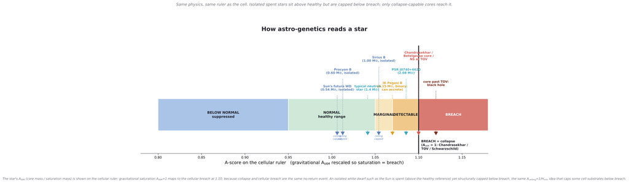

The same gauge read on a star. The cellular and cosmic readings are one instrument at two scales - the author's figure. **Reference figure** - the same in every report, not this specimen.

**Go deeper on the framework and its lineage.** Everything on this tab is treated at full length in the Operations Manual - [MethylPhys CPG Operations Manual](https://github.com/hmahaffeyges/IAM-Validation/blob/a7a4400/Biological_Physics/MethylPhys/manual/MethylPhys_CPG_Operations_Manual.pdf) (the physics section, every sealed procedure with its outcome as found, the complete validation history, the reconciliation tables, the falsification register and the future-goals list) - and in the short methods paper, [Physics of Methylation: Landauer Metrology (PDF)](https://github.com/hmahaffeyges/IAM-Validation/blob/a7a4400/Biological_Physics/MethylPhys/papers/Physics_of_Methylation__Landauer_Metrology.pdf). Both live in the same repository as the code that produced this page, at the same commit.

Reference material - this tab is the same in every report and carries no measurement of this specimen.

https://github.com/hmahaffeyges/IAM-Validation